# Project : Airline on-time performance (exploratory analysis)

We will explore :

```python
# Mean delay per company
mean_delay_per_company_2008 = delayed_flight_df.query("Year=={}".format(2008)) \
                                               .groupby(["Origin"]) \
                                               .mean()

mean_delay_per_company_2008
```

| Origin | Year | Month | DayofMonth | DayOfWeek | DepTime | CRSDepTime | ArrTime | CRSArrTime | FlightNum | ActualElapsedTime | ... | Distance | TaxiIn | TaxiOut | Cancelled | Diverted | CarrierDelay | WeatherDelay | NASDelay | SecurityDelay | LateAircraftDelay |
| --- | --- | --- | --- | --- | --- | --- | --- | --- | --- | --- | --- | --- | --- | --- | --- | --- | --- | --- | --- | --- | --- |
| ABE | 2008.0 | 2.256881 | 14.617737 | 3.899083 | 1275.993884 | 1189.651376 | 1451.174312 | 1349.941896 | 4699.844037 | 132.244648 | ... | 552.883792 | 11.113150 | 20.314985 | 0.0 | 0.0 | 21.061162 | 2.923547 | 25.027523 | 0.000000 | 16.623853 |
| ABI | 2008.0 | 2.165354 | 16.669291 | 3.937008 | 1143.102362 | 984.866142 | 1257.157480 | 1082.165354 | 3422.173228 | 67.755906 | ... | 158.000000 | 12.834646 | 16.732283 | 0.0 | 0.0 | 52.559055 | 18.362205 | 19.929134 | 0.000000 | 12.015748 |
| ABQ | 2008.0 | 2.451012 | 14.977390 | 3.971440 | 1526.537882 | 1463.337961 | 1700.713209 | 1647.716779 | 1670.373265 | 114.048393 | ... | 634.353035 | 7.496232 | 13.065450 | 0.0 | 0.0 | 9.596589 | 0.975407 | 9.227687 | 0.012693 | 28.709639 |
| ABY | 2008.0 | 2.440476 | 13.630952 | 4.214286 | 1424.452381 | 1324.476190 | 1493.261905 | 1415.845238 | 4461.726190 | 58.809524 | ... | 146.000000 | 11.880952 | 9.452381 | 0.0 | 0.0 | 37.511905 | 5.345238 | 18.845238 | 0.000000 | 3.333333 |
| ACT | 2008.0 | 2.181034 | 17.974138 | 3.681034 | 1452.663793 | 1368.362069 | 1522.715517 | 1458.491379 | 3258.931034 | 54.879310 | ... | 89.000000 | 12.362069 | 11.034483 | 0.0 | 0.0 | 11.689655 | 3.750000 | 12.060345 | 0.000000 | 30.172414 |
| ... | ... | ... | ... | ... | ... | ... | ... | ... | ... | ... | ... | ... | ... | ... | ... | ... | ... | ... | ... | ... | ... |
| WRG | 2008.0 | 2.045455 | 14.136364 | 3.954545 | 1405.272727 | 1314.636364 | 1463.863636 | 1366.250000 | 64.522727 | 35.863636 | ... | 55.340909 | 5.000000 | 10.931818 | 0.0 | 0.0 | 5.090909 | 6.227273 | 7.068182 | 0.000000 | 39.227273 |
| XNA | 2008.0 | 2.437112 | 15.601708 | 3.645963 | 1260.694099 | 1173.839286 | 1462.018634 | 1372.795807 | 4071.163043 | 125.361801 | ... | 605.166925 | 11.168478 | 21.896739 | 0.0 | 0.0 | 15.747671 | 4.204969 | 26.927795 | 0.000000 | 21.348602 |
| YAK | 2008.0 | 2.152174 | 13.608696 | 4.130435 | 1572.260870 | 1453.695652 | 1605.326087 | 1542.652174 | 62.956522 | 50.456522 | ... | 207.521739 | 3.804348 | 8.978261 | 0.0 | 0.0 | 2.347826 | 1.043478 | 3.608696 | 0.000000 | 69.586957 |
| YKM | 2008.0 | 2.303030 | 16.666667 | 4.181818 | 817.212121 | 798.484848 | 1100.772727 | 1044.242424 | 3854.742424 | 107.803030 | ... | 586.000000 | 6.924242 | 16.151515 | 0.0 | 0.0 | 9.409091 | 2.757576 | 4.090909 | 0.000000 | 13.000000 |
| YUM | 2008.0 | 2.110048 | 14.598086 | 4.196172 | 1448.693780 | 1400.440191 | 1500.435407 | 1491.856459 | 4073.732057 | 74.995215 | ... | 231.645933 | 8.406699 | 16.674641 | 0.0 | 0.0 | 28.684211 | 0.000000 | 8.086124 | 2.770335 | 10.186603 |

291 rows × 24 columns

```python
# delayed_flight_df[["DepDelay","Origin"]].groupby(["Origin"]).mean() \
#                                                                   .sort_values(by="DepDelay",ascending=False)
```

```python
# # Total delay per company
# total_delay_per_company = delayed_flight_df[["DepDelay","Origin"]].groupby(["Origin"]).sum() \
#                                                                   .sort_values(by="DepDelay",ascending=False)

# total_delay_per_company
```

| Origin | DepDelay |
| --- | --- |
| ORD | 20825544.0 |
| ATL | 19725058.0 |
| DFW | 12421968.0 |
| EWR | 8621867.0 |
| DEN | 8162974.0 |
| ... | ... |
| PIR | 182.0 |
| CKB | 150.0 |
| OGD | 108.0 |
| CYS | 105.0 |
| MKC | 8.0 |

315 rows × 1 columns

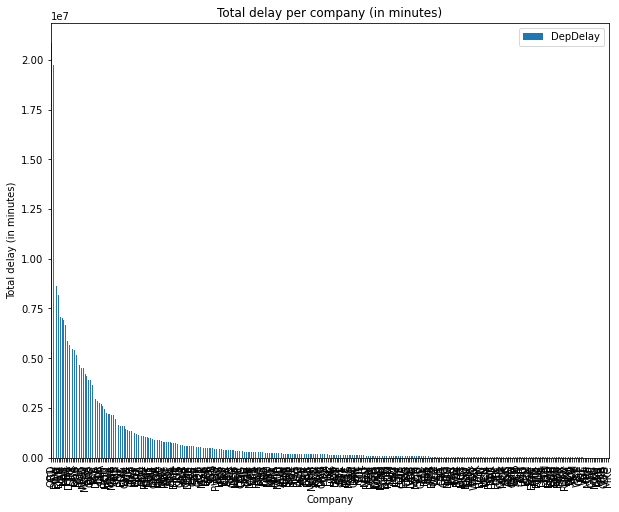

```python
# # Plot total delay per company
# total_delay_per_company.plot(kind="bar", figsize=(10,8))

# plt.xlabel("Company")
# plt.ylabel("Total delay (in minutes)")

# plt.title("Total delay per company (in minutes)");
```

```python
target_variables = ["Origin"]+delay_variables
target_variables
```

```
['Origin',
 'CarrierDelay',
 'WeatherDelay',
 'NASDelay',
 'SecurityDelay',
 'LateAircraftDelay']
```

```python
total_delay_per_reason_per_company = delayed_flight_df[ target_variables ].groupby([ "Origin" ]).sum()

total_delay_per_reason_per_company
```

| Origin | CarrierDelay | WeatherDelay | NASDelay | SecurityDelay | LateAircraftDelay |
| --- | --- | --- | --- | --- | --- |
| ABE | 62568.0 | 16037.0 | 82080.0 | 153.0 | 43400.0 |
| ABI | 42366.0 | 11057.0 | 17415.0 | 201.0 | 20293.0 |
| ABQ | 248755.0 | 33557.0 | 203337.0 | 1276.0 | 544625.0 |
| ABY | 24013.0 | 6575.0 | 23199.0 | 355.0 | 3379.0 |
| ACK | 2972.0 | 457.0 | 16439.0 | 81.0 | 10059.0 |
| ... | ... | ... | ... | ... | ... |
| WYS | 967.0 | 586.0 | 227.0 | 15.0 | 2193.0 |
| XNA | 184741.0 | 36057.0 | 257860.0 | 188.0 | 199511.0 |
| YAK | 2822.0 | 445.0 | 2219.0 | 69.0 | 24903.0 |
| YKM | 3795.0 | 701.0 | 594.0 | 0.0 | 2033.0 |
| YUM | 52672.0 | 2670.0 | 11168.0 | 831.0 | 20923.0 |

315 rows × 5 columns

```python
# # Plot general mean delay of a flight per reason
# mean_of_delays_per_reason.plot(kind="bar", figsize=(10,6))

# plt.xlabel("Delay reasons")
# plt.ylabel("Mean delay (in minutes)")
# plt.title("Mean delay per reason (in minutes)")

# plt.xticks(rotation=15);
```

```python
delayed_flight_df.head().T
```

|  | 4 | 5 | 6 | 7 | 10 |
| --- | --- | --- | --- | --- | --- |
| Year | 2005 | 2005 | 2005 | 2005 | 2005 |
| Month | 1 | 1 | 1 | 1 | 1 |
| DayofMonth | 2 | 3 | 4 | 6 | 10 |
| DayOfWeek | 7 | 1 | 2 | 4 | 1 |
| DepTime | 1934 | 2042 | 2046 | 2110 | 1917 |
| CRSDepTime | 1900 | 1900 | 1900 | 1900 | 1900 |
| ArrTime | 2235 | 9 | 2357 | 8 | 2240 |
| CRSArrTime | 2232 | 2232 | 2232 | 2223 | 2223 |
| UniqueCarrier | UA | UA | UA | UA | UA |
| FlightNum | 542 | 542 | 542 | 542 | 542 |
| TailNum | N902UA | N904UA | N942UA | N920UA | N934UA |
| ActualElapsedTime | 121.0 | 147.0 | 131.0 | 118.0 | 143.0 |
| CRSElapsedTime | 152.0 | 152.0 | 152.0 | 143.0 | 143.0 |
| AirTime | 106.0 | 97.0 | 100.0 | 101.0 | 116.0 |
| ArrDelay | 3.0 | 97.0 | 85.0 | 105.0 | 17.0 |
| DepDelay | 34.0 | 102.0 | 106.0 | 130.0 | 17.0 |
| Origin | ORD | ORD | ORD | ORD | ORD |
| Dest | BOS | BOS | BOS | BOS | BOS |
| Distance | 867 | 867 | 867 | 867 | 867 |
| TaxiIn | 5.0 | 3.0 | 5.0 | 2.0 | 3.0 |
| TaxiOut | 10.0 | 47.0 | 26.0 | 15.0 | 24.0 |
| Cancelled | 0 | 0 | 0 | 0 | 0 |
| Diverted | 0 | 0 | 0 | 0 | 0 |
| CarrierDelay | 0.0 | 23.0 | 46.0 | 16.0 | 17.0 |
| WeatherDelay | 0.0 | 0.0 | 0.0 | 0.0 | 0.0 |
| NASDelay | 0.0 | 0.0 | 0.0 | 0.0 | 0.0 |
| SecurityDelay | 0.0 | 0.0 | 0.0 | 0.0 | 0.0 |
| LateAircraftDelay | 0.0 | 74.0 | 39.0 | 89.0 | 0.0 |

```python
# delayed_flight_df["Origin"].unique()
```

```
array(['ORD', 'BOS', 'SMF', 'SAN', 'MIA', 'SFO', 'DEN', 'DSM', 'ROC',
       'LAX', 'SEA', 'DAY', 'ALB', 'PIT', 'MDT', 'BUR', 'MHT', 'SAT',
       'SNA', 'CLT', 'GEG', 'SLC', 'BOI', 'IND', 'MCI', 'MSP', 'OAK',
       'DFW', 'PDX', 'PHL', 'ATL', 'RIC', 'MSY', 'EGE', 'SJC', 'BWI',
       'OMA', 'DCA', 'STL', 'PSP', 'ABQ', 'EWR', 'COS', 'CMH', 'LGA',
       'IAD', 'BUF', 'DTW', 'OKC', 'TUS', 'PVD', 'BDL', 'RSW', 'ANC',
       'IAH', 'AUS', 'SJU', 'CLE', 'CVG', 'ICT', 'JFK', 'HNL', 'OGG',
       'PHX', 'GUC', 'MTJ', 'KOA', 'STT', 'RNO', 'GSO', 'GRR', 'BIL',
       'BTV', 'TUL', 'FLL', 'LAS', 'MCO', 'TPA', 'ONT', 'BNA', 'JAX',
       'MYR', 'SYR', 'RDU', 'BHM', 'SAV', 'PBI', 'ORF', 'CHS', 'STX',
       'ILM', 'ABE', 'PWM', 'MKE', 'CRP', 'DAL', 'ELP', 'HOU', 'HRL',
       'ISP', 'JAN', 'LBB', 'LIT', 'MDW', 'SDF', 'AMA', 'MAF', 'GFK',
       'FSD', 'MEM', 'FAR', 'MSN', 'XNA', 'DLH', 'BTR', 'FCA', 'MBS',
       'CID', 'LAN', 'GRB', 'GPT', 'RAP', 'BZN', 'LSE', 'MOT', 'MSO',
       'BIS', 'RST', 'FNT', 'SRQ', 'JAC', 'HDN', 'TVC', 'AZO', 'HPN',
       'VPS', 'LEX', 'GSP', 'AVP', 'BGR', 'HVN', 'CRW', 'CAK', 'SBN',
       'ROA', 'DAB', 'TRI', 'ERI', 'CHO', 'CMI', 'FWA', 'ATW', 'HLN',
       'SHV', 'SCE', 'HSV', 'CHA', 'TOL', 'EVV', 'CAE', 'TYS', 'PHF',
       'SGF', 'TLH', 'SWF', 'AVL', 'ACY', 'BGM', 'MLI', 'HTS', 'SBA',
       'MLB', 'PFN', 'PNS', 'GJT', 'TWF', 'PIH', 'SGU', 'COD', 'EKO',
       'IDA', 'PSC', 'GTF', 'BTM', 'FAT', 'ACV', 'CIC', 'OXR', 'SBP',
       'YUM', 'MOD', 'MRY', 'RDD', 'MFR', 'CPR', 'EUG', 'LNK', 'BPT',
       'MLU', 'VCT', 'BFL', 'CLD', 'VIS', 'IYK', 'SMX', 'CEC', 'RDM',
       'PIA', 'GRK', 'SJT', 'ACT', 'CLL', 'TYR', 'IPL', 'DRO', 'ABI',
       'TXK', 'SUN', 'CDC', 'CYS', 'LFT', 'AEX', 'LCH', 'MOB', 'LRD',
       'BRO', 'MFE', 'PIE', 'LIH', 'AGS', 'CSG', 'DHN', 'GNV', 'APF',
       'MGM', 'VLD', 'ABY', 'GTR', 'LYH', 'MEI', 'EYW', 'FAY', 'FLO',
       'MCN', 'BQK', 'BMI', 'ITO', 'LGB', 'LAW', 'SPS', 'GGG', 'FSM',
       'DBQ', 'MQT', 'FAI', 'ADQ', 'DLG', 'BET', 'SCC', 'JNU', 'KTN',
       'CDV', 'YAK', 'SIT', 'PSG', 'WRG', 'AKN', 'ADK', 'BRW', 'OME',
       'OTZ', 'BQN', 'LWS', 'ISO', 'LWB', 'HKY', 'WYS', 'ACK', 'TUP',
       'GST', 'PSE', 'OGD', 'SPI', 'CWA', 'CKB', 'ASE', 'TEX', 'OAJ',
       'FLG', 'RFD', 'BLI', 'SOP', 'ILG', 'TTN', 'CMX', 'RHI', 'ALO',
       'SUX', 'PLN', 'ELM', 'MTH', 'EAU', 'HHH', 'MKC', 'EWN', 'YKM',
       'PMD', 'SLE', 'INL', 'BJI', 'ROW', 'PIR', 'RKS', 'GCC', 'MKG'],
      dtype=object)
```

```python
# delayed_flight_df["Dest"].unique()
```

```python
airport_df.head()
```

|  | iata | airport | city | state | country | lat | long |
| --- | --- | --- | --- | --- | --- | --- | --- |
| 0 | 00M | Thigpen | Bay Springs | MS | USA | 31.953765 | -89.234505 |
| 1 | 00R | Livingston Municipal | Livingston | TX | USA | 30.685861 | -95.017928 |
| 2 | 00V | Meadow Lake | Colorado Springs | CO | USA | 38.945749 | -104.569893 |
| 3 | 01G | Perry-Warsaw | Perry | NY | USA | 42.741347 | -78.052081 |
| 4 | 01J | Hilliard Airpark | Hilliard | FL | USA | 30.688012 | -81.905944 |

```python
airport_df["iata"].unique()
```

```
array(['00M', '00R', '00V', ..., 'ZPH', 'ZUN', 'ZZV'], dtype=object)
```

```python
# Retrieve flights data are ahead of the scheduled time data
ahead_flight_df = flight_df.query("ArrDelay <0 ")
print(ahead_flight_df.shape)
ahead_flight_df.head(10).T
```

|  | 0 | 1 | 2 | 3 | 9 | 15 | 20 | 21 | 22 | 23 |
| --- | --- | --- | --- | --- | --- | --- | --- | --- | --- | --- |
| Year | 2005 | 2005 | 2005 | 2005 | 2005 | 2005 | 2005 | 2005 | 2005 | 2005 |
| Month | 1 | 1 | 1 | 1 | 1 | 1 | 1 | 1 | 1 | 1 |
| DayofMonth | 28 | 29 | 30 | 31 | 9 | 17 | 25 | 27 | 28 | 30 |
| DayOfWeek | 5 | 6 | 7 | 1 | 7 | 1 | 2 | 4 | 5 | 7 |
| DepTime | 1603 | 1559 | 1603 | 1556 | 1859 | 1859 | 1849 | 1859 | 1855 | 1858 |
| CRSDepTime | 1605 | 1605 | 1610 | 1605 | 1900 | 1900 | 1900 | 1900 | 1900 | 1900 |
| ArrTime | 1741 | 1736 | 1741 | 1726 | 2205 | 2202 | 2200 | 2215 | 2218 | 2212 |
| CRSArrTime | 1759 | 1759 | 1805 | 1759 | 2223 | 2223 | 2223 | 2223 | 2223 | 2223 |
| UniqueCarrier | UA | UA | UA | UA | UA | UA | UA | UA | UA | UA |
| FlightNum | 541 | 541 | 541 | 541 | 542 | 542 | 542 | 542 | 542 | 542 |
| TailNum | N935UA | N941UA | N342UA | N326UA | N929UA | N902UA | N929UA | N927UA | N923UA | N920UA |
| ActualElapsedTime | 158.0 | 157.0 | 158.0 | 150.0 | 126.0 | 123.0 | 131.0 | 136.0 | 143.0 | 134.0 |
| CRSElapsedTime | 174.0 | 174.0 | 175.0 | 174.0 | 143.0 | 143.0 | 143.0 | 143.0 | 143.0 | 143.0 |
| AirTime | 131.0 | 136.0 | 131.0 | 129.0 | 106.0 | 109.0 | 108.0 | 115.0 | 111.0 | 117.0 |
| ArrDelay | -18.0 | -23.0 | -24.0 | -33.0 | -18.0 | -21.0 | -23.0 | -8.0 | -5.0 | -11.0 |
| DepDelay | -2.0 | -6.0 | -7.0 | -9.0 | -1.0 | -1.0 | -11.0 | -1.0 | -5.0 | -2.0 |
| Origin | BOS | BOS | BOS | BOS | ORD | ORD | ORD | ORD | ORD | ORD |
| Dest | ORD | ORD | ORD | ORD | BOS | BOS | BOS | BOS | BOS | BOS |
| Distance | 867 | 867 | 867 | 867 | 867 | 867 | 867 | 867 | 867 | 867 |
| TaxiIn | 4.0 | 6.0 | 9.0 | 11.0 | 5.0 | 3.0 | 4.0 | 8.0 | 7.0 | 7.0 |
| TaxiOut | 23.0 | 15.0 | 18.0 | 10.0 | 15.0 | 11.0 | 19.0 | 13.0 | 25.0 | 10.0 |
| Cancelled | 0 | 0 | 0 | 0 | 0 | 0 | 0 | 0 | 0 | 0 |
| Diverted | 0 | 0 | 0 | 0 | 0 | 0 | 0 | 0 | 0 | 0 |
| CarrierDelay | 0.0 | 0.0 | 0.0 | 0.0 | 0.0 | 0.0 | 0.0 | 0.0 | 0.0 | 0.0 |
| WeatherDelay | 0.0 | 0.0 | 0.0 | 0.0 | 0.0 | 0.0 | 0.0 | 0.0 | 0.0 | 0.0 |
| NASDelay | 0.0 | 0.0 | 0.0 | 0.0 | 0.0 | 0.0 | 0.0 | 0.0 | 0.0 | 0.0 |
| SecurityDelay | 0.0 | 0.0 | 0.0 | 0.0 | 0.0 | 0.0 | 0.0 | 0.0 | 0.0 | 0.0 |
| LateAircraftDelay | 0.0 | 0.0 | 0.0 | 0.0 | 0.0 | 0.0 | 0.0 | 0.0 | 0.0 | 0.0 |

## Univariate Exploration

> In this section, investigate distributions of individual variables. If you see unusual points or outliers, take a deeper look to clean things up and prepare yourself to look at relationships between variables.

> **Rubric Tip**: The project (Parts I alone) should have at least 15 visualizations distributed over univariate, bivariate, and multivariate plots to explore many relationships in the data set. Use reasoning to justify the flow of the exploration.

> **Rubric Tip**: Use the "Question-Visualization-Observations" framework throughout the exploration. This framework involves **asking a question from the data, creating a visualization to find answers, and then recording observations after each visualisation.**

> **Rubric Tip**: Visualizations should depict the data appropriately so that the plots are easily interpretable. You should choose an appropriate plot type, data encodings, and formatting as needed. The formatting may include setting/adding the title, labels, legend, and comments. Also, do not overplot or incorrectly plot ordinal data.

## Bivariate Exploration

> In this section, investigate relationships between pairs of variables in your data. Make sure the variables that you cover here have been introduced in some fashion in the previous section (univariate exploration).

## Multivariate Exploration

> Create plots of three or more variables to investigate your data even further. Make sure that your investigations are justified, and follow from your work in the previous sections.

## Conclusions

> Remove all Tips mentioned above, before you convert this notebook to PDF/HTML

> At the end of your report, make sure that you export the notebook as an html file from the `File > Download as... > HTML or PDF` menu. Make sure you keep track of where the exported file goes, so you can put it in the same folder as this notebook for project submission. Also, make sure you remove all of the quote-formatted guide notes like this one before you finish your report!